# Assignment3

Gaurav Bhardwaj

3/29/2018

```r
df = read_csv('Data/kickstarter_projects.csv')
df <- df %>% filter(
  is.na(df$goal)==FALSE &
      is.na(df$pledged)==FALSE)
head(data)
```

[output not shown]

# 1: Identifying Successful Projects

## 1(a)

1. Success by Category There are several ways to identify success of a project:
- State (state): Whether a campaign was successful or not.
- Pledged Amount (pledged) - Achievement Ratio: Create a variable achievement_ratio by calculating the percentage of the original monetary goal divided by the actual amount pledged.
- Number of backers (backers_count) - How quickly the goal was reached (difference between launched_at and state_changed_at) for those campaigns that were successful.

Use one or more of these measures to visually summarize which categories were most successful in attracting funding on kickstarter. Briefly summarize your findings.

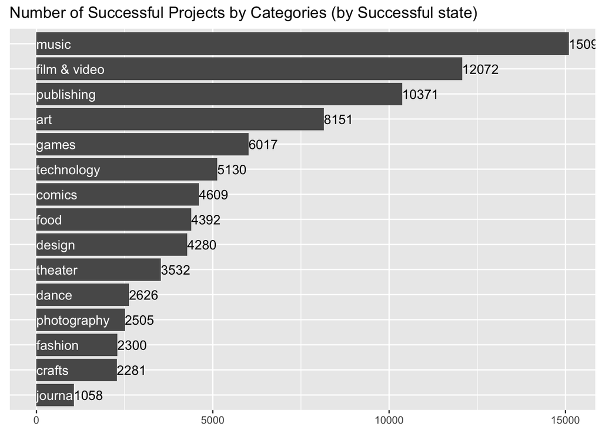

```r
success_data <- filter(df, state=='successful')

state_int<- as.factor(success_data$state)
levels(state_int) <- 1:length(levels(state_int))
success_data$state_int <- as.numeric(state_int)

success_data %>% group_by(top_category) %>%summarize(m=n())%>%
                mutate(top_category= reorder(top_category, m)) %>%
ggplot(aes(top_category, m)) +
  geom_bar(stat = "identity") +
  geom_text(aes(label=top_category, x=top_category, y=0), hjust = 0, color="white") +
  geom_text(aes(label=m, x=top_category, y=m), hjust = 0, color="black") +
  xlab("Categories")+ ylab(NULL) +  coord_flip() +
  theme(axis.title.y=element_blank(),
        axis.text.y=element_blank(),
        axis.ticks.y=element_blank()) +
  ggtitle("Number of Successful Projects by Categories (by Successful state)")
```

```r
df$achievement_ratio <- (df$pledged / df$goal)*100
```

[figure not shown]

```r
#sub_data <- filter(df, achievement_ratio>=100)

df %>% group_by(top_category) %>%summarize(m=n())%>%
                mutate(top_category= reorder(top_category, m)) %>%
ggplot(aes(top_category, m)) +
  geom_bar(stat = "identity") +
  geom_text(aes(label=top_category, x=top_category, y=0),hjust = 0, color="white") +
  geom_text(aes(label=m, x=top_category, y=m), hjust = 0, color="black") +
  xlab("Categories")+ ylab(NULL) +  coord_flip() +
  theme(axis.title.y=element_blank(),
        axis.text.y=element_blank(),
        axis.ticks.y=element_blank()) +
  ggtitle("Number of Successful Projects by Categories (by achievement ratio)")
```

# 2

Each project contains a blurb – a short description of the project. While not the full description of the project, the short headline is arguably important for inducing interest in the project (and ultimately popularity and success). Let’s analyze the text.

## 2(a) Cleaning the Text and Word Cloud

To reduce the time for analysis, select the 1000 most successful projects and a sample of 1000 unsuccessful projects. Use the cleaning functions introduced in lecture (or write your own in addition) to remove unnecessary words (stop words), syntax, punctuation, numbers, white space etc. Note, that many projects use their own unique brand names in upper cases, so try to remove these fully capitalized words as well (since we are aiming to identify common words across descriptions). Stem the words left and complete the stems. Create a document-term-matrix.

Provide a word cloud of the most frequent or important words (your choice which frequency measure you choose) among the most successful projects.

- select the 1000 most successful projects
- sample of 1000 unsuccessful projects
- Use the cleaning functions
- remove unique brand names in upper cases
- Stem the words left and complete the stems
- Create a document-term-matrix

```r
sub <- df[, c("blurb", "top_category","achievement_ratio")]
sub <- sub[order(-df$achievement_ratio),]

sub <-  sub[!duplicated(df[,c("blurb")]),]

low1000 <- sub[(nrow(sub)-1000):nrow(sub),]
top1000 <- sub[1:1001,]

df_all <- merge(low1000, top1000, all=TRUE)

corp_low <- Corpus(VectorSource(low1000$blurb))

corp_top <- Corpus(VectorSource(top1000$blurb))

corp_all <- Corpus((VectorSource(df_all$blurb)))


removeNumPunct <- function(x){gsub("[^[:alpha:][:space:]]*", "", x)}
remove_allcaps <- function(x){gsub("\\b[A-Z]+\\b", "", x)}
remove_wwwwords <- function(x){gsub("www+[a-z]+[:space:]", "", x)}
remove_comwords <- function(x){gsub("[a-z]+com", "", x)}
clean_corpus <- function(corpus){
  corpus <- tm_map(corpus, content_transformer(remove_allcaps))
  corpus <- tm_map(corpus, removePunctuation)
  corpus <- tm_map(corpus, content_transformer(remove_wwwwords))
  corpus <- tm_map(corpus, content_transformer(remove_comwords))
  corpus <- tm_map(corpus, content_transformer(tolower))
  #corpus <- tm_map(corpus, content_transformer(replace_symbol))
  corpus <- tm_map(corpus, removeWords, c(stopwords("en")))
    # We could add more stop words as above
  corpus <- tm_map(corpus, removeNumbers)
  corpus <- tm_map(corpus, content_transformer(removeNumPunct))
  corpus <- tm_map(corpus, stripWhitespace)
  return(corpus)
}

clean_1000low <- clean_corpus(corp_low)
clean_1000top <- clean_corpus(corp_top)
clean_all <- clean_corpus(corp_all)
```

```r
stemmed_1000low <- tm_map(clean_1000low, stemDocument)
stemmed_1000top <- tm_map(clean_1000top, stemDocument)
stemmed_all <- tm_map(clean_all, stemDocument)

stemCompletion2 <- function(x, dictionary) {
   x <- unlist(strsplit(as.character(x), " "))
    # # Oddly, stemCompletion completes an empty string to
      # a word in dictionary. Remove empty string to avoid issue.
   x <- x[x != ""]
   x <- stemCompletion(x, dictionary=dictionary)
   x <- paste(x, sep="", collapse=" ")
   PlainTextDocument(stripWhitespace(x))
}


stem_low1000 <- lapply(stemmed_1000low, stemCompletion2,
                     dictionary=clean_1000low)

for (i in 1:length(stem_low1000)) {
  meta(stem_low1000[[i]]) <- NULL
}

stem_top1000 <- lapply(stemmed_1000top, stemCompletion2,
                     dictionary=clean_1000top)

for (i in 1:length(stem_top1000)) {
  meta(stem_top1000[[i]]) <- NULL
}

stem_all <- lapply(stemmed_all, stemCompletion2,
                   dictionary=clean_all)

for (i in 1:length(stem_all)) {
  meta(stem_all[[i]]) <- NULL
}
```

Converting TDM to matirices

```r
## Creaying TDMs

low1000_comp_all <- Corpus(VectorSource(stem_low1000))

low1000_comp_all <- tm_map(low1000_comp_all, removeWords, c("list", "content"))

top1000_comp_all <- Corpus(VectorSource(stem_top1000))

top1000_comp_all <- tm_map(top1000_comp_all, removeWords, c("list", "content"))

all_comp <- Corpus(VectorSource(stem_all))

all_comp <- tm_map(all_comp, removeWords, c("list", "content"))

low1000_tdm <- TermDocumentMatrix(low1000_comp_all)

top1000_tdm <- TermDocumentMatrix(top1000_comp_all)

all_tdm <- TermDocumentMatrix(all_comp)

low1000_m <- as.matrix(low1000_tdm)

top1000_m <- as.matrix(top1000_tdm)

all_m <- as.matrix(all_tdm)
```

```r
## Tidying objects

low1000_tidy <- tidy(low1000_tdm)
head(low1000_tidy)
```

```
## # A tibble: 6 x 3
##   term       document count
##   <chr>      <chr>    <dbl>
## 1 allow      1         1.00
## 2 analyze    1         1.00
## 3 applicable 1         1.00
## 4 dream      1         1.00
## 5 interpret  1         1.00
## 6 mobile     1         1.00
```

```r
top1000_tidy <- tidy(top1000_tdm)
head(top1000_tidy)
```

```
## # A tibble: 6 x 3
##   term                                 document count
##   <chr>                                <chr>    <dbl>
## 1 creator                              1         1.00
## 2 fristrom                             1         1.00
## 3 game                                 1         2.00
## 4 grappleandswingandrunonwallsforstyle 1         1.00
## 5 hook                                 1         1.00
## 6 jamie                                1         1.00
```

```r
all_tidy <- tidy(all_tdm)
head(all_tidy)
```

```
## # A tibble: 6 x 3
##   term       document count
##   <chr>      <chr>    <dbl>
## 1 acceptance 1         1.00
## 2 expect     1         1.00
## 3 forgive    1         1.00
## 4 love       1         2.00
## 5 message    1         1.00
## 6 people     1         1.00
```

Creating frequency plot

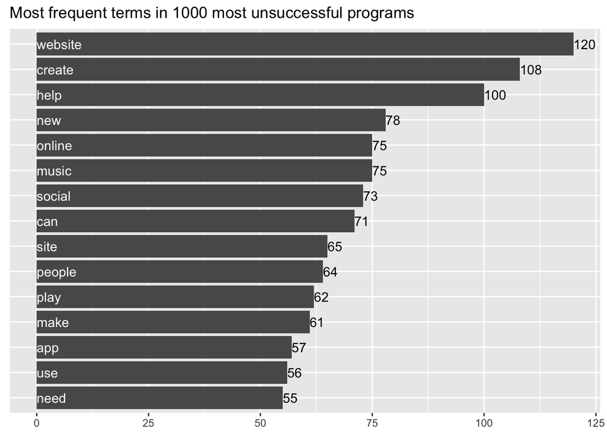

```r
low1000_tidy %>%     group_by(term) %>%
                summarise(n = sum(count)) %>%
                top_n(n = 15)  %>%
                ungroup() %>%
                mutate(term = reorder(term, n)) %>%
ggplot(aes(term, n)) +
  geom_bar(stat = "identity") +
  geom_text(aes(label=term, x=term, y=0),hjust = 0, color="white") +
  geom_text(aes(label=n, x=term, y=n), hjust = 0, color="black") +
  xlab(NULL)+ ylab(NULL) +  coord_flip() +
  theme(axis.title.y=element_blank(),
        axis.text.y=element_blank(),
        axis.ticks.y=element_blank()) +
  ggtitle("Most frequent terms in 1000 most unsuccessful programs")
```

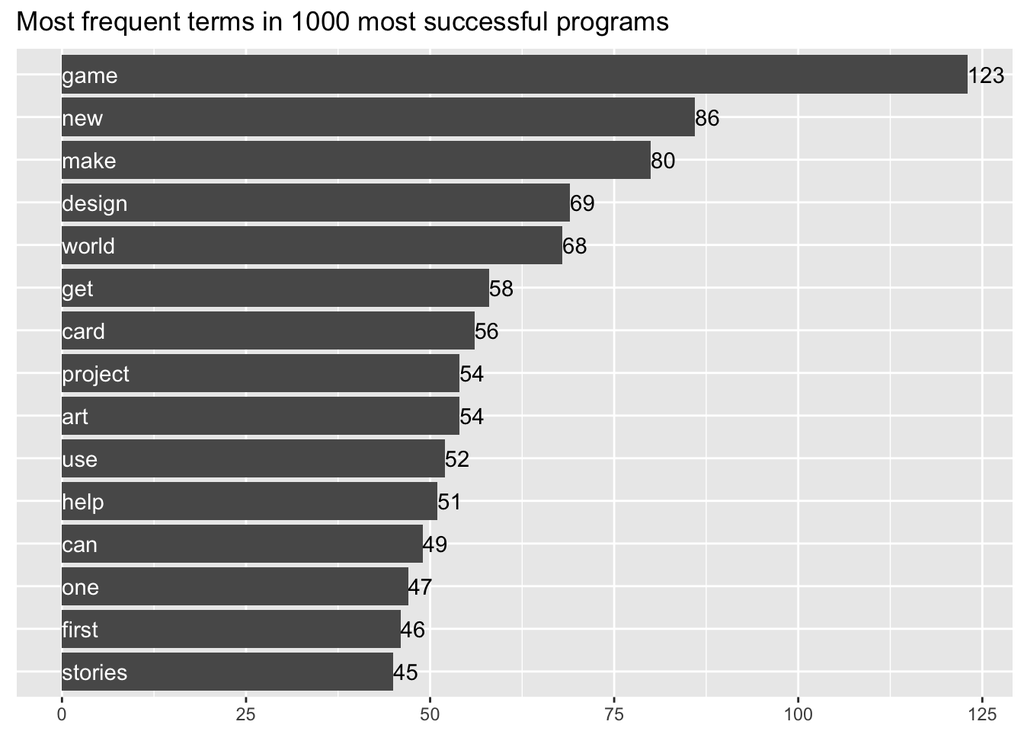

```r
top1000_tidy %>%     group_by(term) %>%
                summarise(n = sum(count)) %>%
                top_n(n = 15, wt = n)  %>%
                ungroup() %>%
                mutate(term = reorder(term, n)) %>%
ggplot(aes(term, n)) +
  geom_bar(stat = "identity") +
  geom_text(aes(label=term, x=term, y=0),hjust = 0, color="white") +
  geom_text(aes(label=n, x=term, y=n), hjust = 0, color="black") +
  xlab(NULL)+ ylab(NULL) +  coord_flip() +
  theme(axis.title.y=element_blank(),
        axis.text.y=element_blank(),
        axis.ticks.y=element_blank()) +
  ggtitle("Most frequent terms in 1000 most successful programs")
```

## IDF matrices for all the categories

```r
low1000_tf_idf <-  low1000_tidy %>%
                bind_tf_idf(term, document, count) %>%
                arrange(desc(tf_idf))
low1000_tf_idf
```

```
## # A tibble: 10,562 x 6
##    term      document count    tf   idf tf_idf
##    <chr>     <chr>    <dbl> <dbl> <dbl>  <dbl>
##  1 gjup      803       1.00 1.00   6.90   6.90
##  2 check     841       1.00 1.00   5.11   5.11
##  3 debating  243       1.00 0.500  6.90   3.45
##  4 movement  282       1.00 0.500  5.52   2.76
##  5 gamer     326       1.00 0.500  5.29   2.65
##  6 woman     802       2.00 0.500  5.29   2.65
##  7 dongle    134       1.00 0.333  6.90   2.30
##  8 beach     325       2.00 0.333  6.21   2.07
##  9 behind    555       1.00 0.333  6.21   2.07
## 10 wonderful 555       1.00 0.333  6.21   2.07
## # ... with 10,552 more rows
```

```r
top1000_tf_idf <-  top1000_tidy %>%
                bind_tf_idf(term, document, count) %>%
                arrange(desc(tf_idf))
top1000_tf_idf
```

```
## # A tibble: 10,220 x 6
##    term    document count    tf   idf tf_idf
##    <chr>   <chr>    <dbl> <dbl> <dbl>  <dbl>
##  1 info    128       1.00 0.500  6.91   3.45
##  2 ninja   814       1.00 0.500  6.91   3.45
##  3 rock    814       1.00 0.500  6.91   3.45
##  4 fish    478       1.00 0.500  5.81   2.90
##  5 may     478       1.00 0.500  5.52   2.76
##  6 extreme 645       1.00 0.500  5.30   2.65
##  7 day     645       1.00 0.500  4.71   2.35
##  8 animals 889       1.00 0.500  4.71   2.35
##  9 barnes  20        1.00 0.333  6.91   2.30
## 10 store   177       1.00 0.333  6.91   2.30
## # ... with 10,210 more rows
```

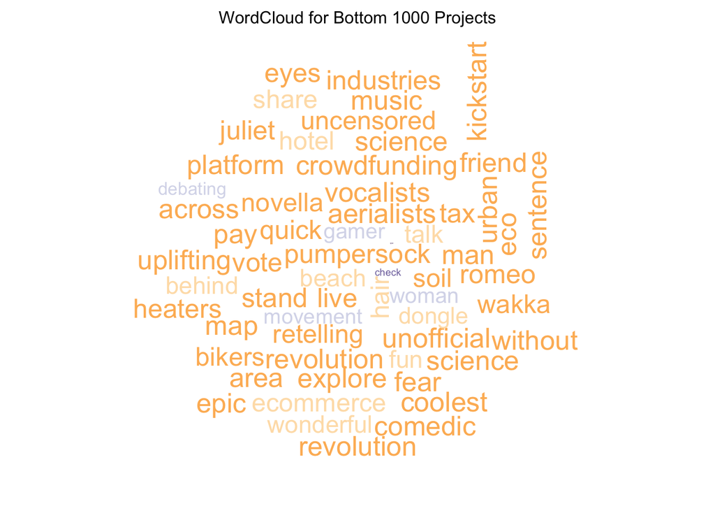

```r
set.seed(1000)
purple_orange <- brewer.pal(10, "PuOr")
purple_orange <- purple_orange[-(1:2)]
# Create a wordcloud for the values in word_freqs
wordcloud(low1000_tf_idf$term, low1000_tf_idf$tf_idf,max.words = 60,
          min.freq=1, scale = c(0.1,2), colors = purple_orange)
text(x=0.5, y=1.0, "WordCloud for Bottom 1000 Projects")
```

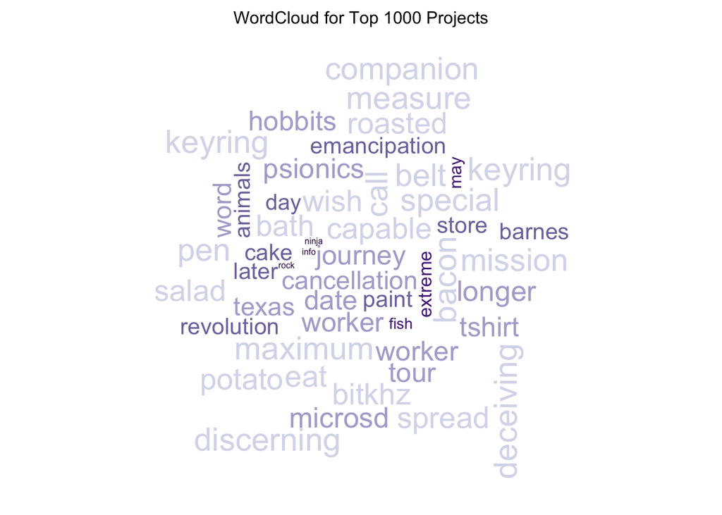

```r
set.seed(1011)
purple_orange <- brewer.pal(10, "PuOr")
purple_orange <- purple_orange[-(1:2)]
# Create a wordcloud for the values in word_freqs
wordcloud(top1000_tf_idf$term, top1000_tf_idf$tf_idf,max.words = 50,
          min.freq=1, scale = c(0.5,3), color =purple_orange )

text(x=0.5, y=1.0, "WordCloud for Top 1000 Projects")
```

# 2(b) Success in words

Provide a pyramid plot to show how the words between successful and unsuccessful projects differ in frequency. A selection of 10 - 20 top words is sufficient here.

```r
corp_top1 <- Corpus(VectorSource(stem_top1000))
corp_top1 <- tm_map(corp_top1, removeWords, c("list", "content"))
dt_mat_top <- DocumentTermMatrix(corp_top1)
corp_low1 <- Corpus(VectorSource(stem_low1000))
corp_low1 <- tm_map(corp_low1, removeWords, c("list", "content"))
dt_mat_low <- DocumentTermMatrix(corp_low1)

top1000_tidy <- tidy(dt_mat_top)
low1000_tidy <- tidy(dt_mat_low)
top20 <- top1000_tidy %>%
              group_by(term) %>%
              summarise(n = sum(count))  %>%
              top_n(n = 20, wt = n) %>%
              rename(successful=n)

low20 <- low1000_tidy %>%
              group_by(term) %>%
              summarise(n = sum(count))  %>%
              top_n(n = 20, wt = n)%>%
              rename(unsuccessful=n)

all20 <- full_join(top20, low20, by="term") %>%
         gather(type, number, -term)
```

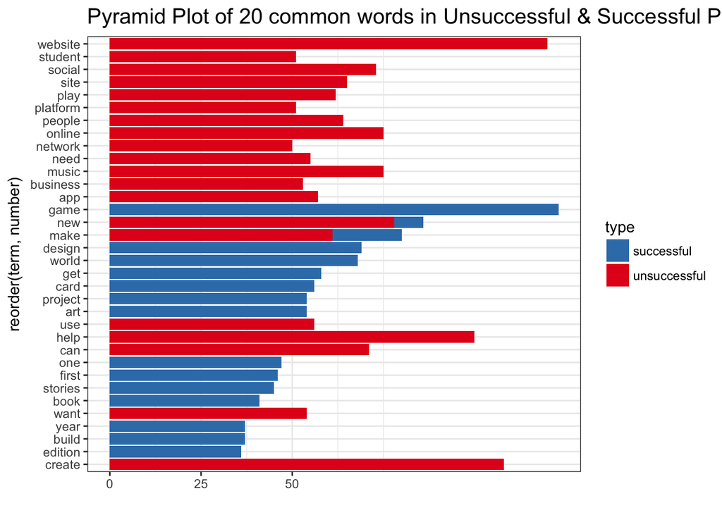

```r
#all20, aes(x = reorder(term, number), y=number, fill=type)
ggplot() +
  geom_bar(data = filter(all20, type =='successful'),aes(x = reorder(term, number), y=number, fill=type), stat = "identity") +
  geom_bar(data = filter(all20, type == "unsuccessful"),aes(x = reorder(term, number), y=number, fill=type), stat = "identity") +
  scale_fill_brewer(palette = "Set1", direction=-1)+coord_flip()  +
  labs(title="Pyramid Plot of 20 common words in Unsuccessful & Successful Projects", fontsize=8)+
  scale_y_continuous(breaks = seq(-50, 50 , 25)) + ylab("")+theme_bw()+
  #theme_fivethirtyeight()+
  theme(plot.title = element_text(size = 15))
```

##### After multiple tries I left the above plot in this way as it wouldn’t split midway.

# c) Simplicity as a virtue

These blurbs are short in length (max. 150 characters) but let’s see whether brevity and simplicity still matters. Calculate a readability measure (Flesh Reading Ease, Flesh Kincaid or any other comparable measure) for the texts. Visualize the relationship between the readability measure and one of the measures of success. Briefly comment on your finding.

```r
require(quanteda)
require(dplyr)
data_corpus <- corpus(all20$term)

FRE_data <- textstat_readability(data_corpus,
              measure=c('Flesch.Kincaid'))
FRE <- data_frame(FK = FRE_data$Flesch.Kincaid,
    category = all20$type ,
    words = ntoken(data_corpus),
    achievement = as.numeric(all20$number))
```

Plotting the FRE

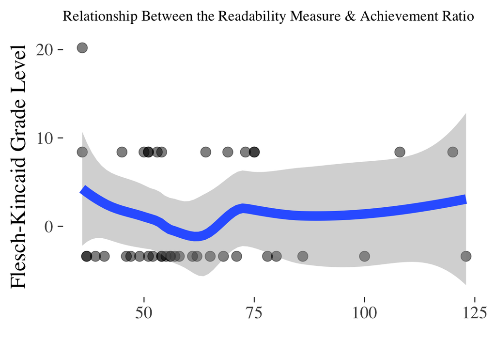

```r
ggplot(data=FRE, aes(x=achievement,y=FK, size=words)) +
  geom_point(alpha=0.5) + geom_smooth() + guides(size=FALSE) +
  theme_tufte(22) + xlab("") + ylab("Flesch-Kincaid Grade Level") + theme(legend.position="none")+
  labs(title='Relationship Between the Readability Measure & Achievement Ratio')+
  theme(plot.title = element_text(size = 15))
```

# 3. Sentiment

Now, let’s check whether the use of positive / negative words or specific emotions helps a project to be successful.

# a) Stay positive

Calculate the tone of each text based on the positive and negative words that are being used. You can rely on the Hu & Liu dictionary provided in lecture or use the Bing dictionary contained in the tidytext package (tidytext::sentiments). Visualize the relationship between tone of the document and success. Briefly comment.

```r
mytext <- get_sentences(sub$blurb)

sent <- sentiment_by(mytext)
```

```r
sub$sentiment <- sent$ave_sentiment
```

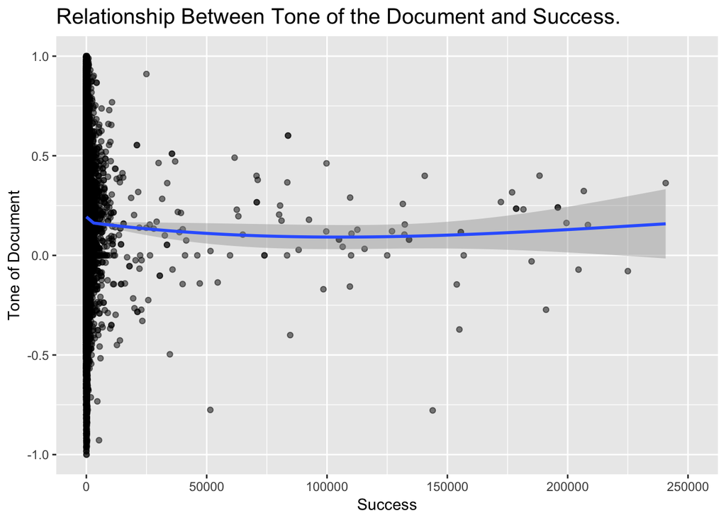

```r
ggplot(data=sub, aes(y=sentiment,x=achievement_ratio)) +
  geom_point(alpha=0.5) + geom_smooth() + xlab("Success") + ylab("Tone of Document") +
  labs(title='Relationship Between Tone of the Document and Success.')+
  theme(plot.title = element_text(size = 15))+ xlim(0,2.5e+05)+ ylim(-1,1)
```

# 2 (b) Positive vs negative

Segregate all 2,000 blurbs into positive and negative texts based on their polarity score calculated in step (a). Now, collapse the positive and negative texts into two larger documents. Create a document-term-matrix based on this collapsed set of two documents. Generate a comparison cloud showing the most-frequent positive and negative words.

```r
pos_words <- readLines("Data/dictionaries/positive-words.txt")
pos_words <- stri_enc_toutf8(pos_words, is_unknown_8bit = T)
negwords <- readLines("Data/dictionaries/negative-words.txt")
negwords <- stri_enc_toutf8(negwords, is_unknown_8bit = T)

allwords <- dictionary(list(positive= pos_words, negative=negwords))


## Function is derived from stackoverflow

dfmat <- function(data){
dfm_ <- dfm(data, dictionary = allwords, tolower = T)
dfm_ <- data.frame(dfm_)
dfm_$tone <- (dfm_$positive - dfm_$negative)/(dfm_$positive + dfm_$negative)
dfm_$estimate <- "Positive"
dfm_$estimate[dfm_$tone < 0] <- "Negative"

return(dfm_)
}
top_dfm <- dfmat(corpus(df$blurb[1:1000]))
top_dfm <- dplyr::mutate(top_dfm, state="successful")

for (i in 1:nrow(top_dfm)){
top_dfm$blurb[i] <- stem_top1000[[i]]$content
}

low_dfm <- dfmat(df$blurb[nrow(df)-1000:nrow(df)])
low_dfm <- dplyr::mutate(low_dfm, state="unsuccessful")

for (i in 1:nrow(top_dfm)){
low_dfm$blurb[i] <- stem_low1000[[i]]$content
}


all_dfm <- rbind(top_dfm, low_dfm)
```

```r
poswords_dfm <- subset(all_dfm, all_dfm$estimate=='Positive')
negwords_dfm <- subset(all_dfm, all_dfm$estimate=='Negative')


corp_top <- Corpus(VectorSource(poswords_dfm$blurb))
corp_low <- Corpus(VectorSource(negwords_dfm$blurb))

topdtm <- DocumentTermMatrix(corp_top)
lowdtm <- DocumentTermMatrix(corp_low)

dmatrix <- function(data){
  matrix <- t(as.matrix(data))
  v <- sort(quanteda::rowSums(matrix),decreasing=TRUE)
  d <- data.frame(word = names(v),freq=v)
  return (d)

}
positive_data <- dmatrix(topdtm)
negative_data <- dmatrix(lowdtm)

combine_data <- merge(positive_data, negative_data,by="word")
rownames(combine_data) <- combine_data$word
colnames(combine_data) <- c("Word","Positive","Negative")
```

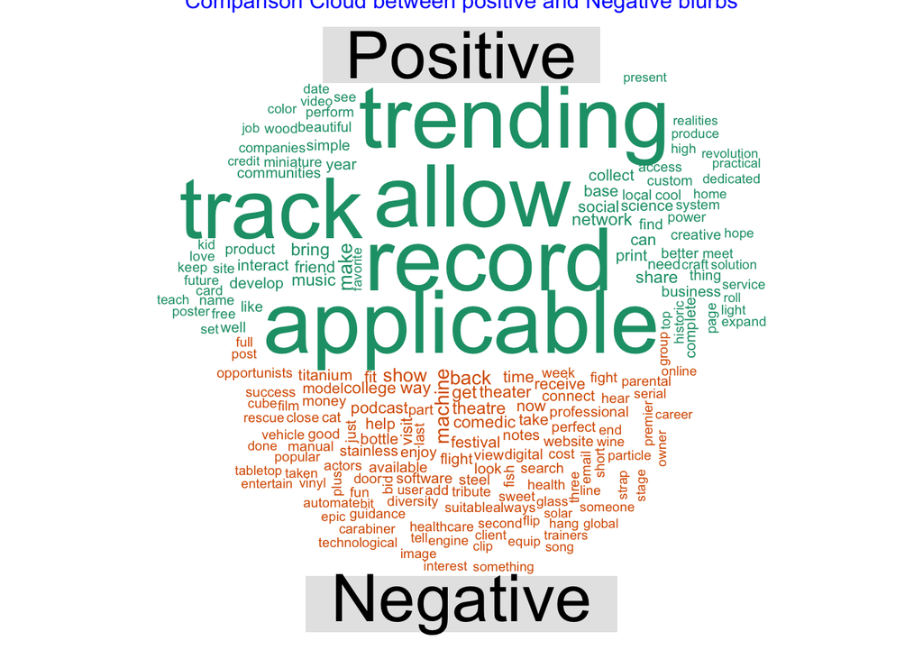

```r
set.seed(123)
c <- comparison.cloud(combine_data[,2:3], max.words = 200, scale=c(4,.5), random.order=FALSE, rot.per=.1,
    colors=brewer.pal(ncol(combine_data[,2:3]),"Dark2"),
    use.r.layout=FALSE) + title("Comparison Cloud between positive and Negative blurbs", cex.main =1,   font.main= 1, col.main= "blue", outer = TRUE)
```

```r
#devtools::install_github("mjockers/syuzhet")
library(syuzhet)
nrc <- get_nrc_sentiment(all_dfm$blurb)
all_data <- cbind(all_dfm, nrc)

all_data <- all_data[,1:15]
data <- all_data %>%  group_by(state) %>%
          summarise(anger= mean(anger),
                    anticipation= mean(anticipation),
                    disgust= mean(disgust),
                    fear= mean(fear),
                    joy= mean(joy),
                    sadness= mean(sadness),
                    surprise= mean(surprise),
                    trust= mean(trust)

                    )
```

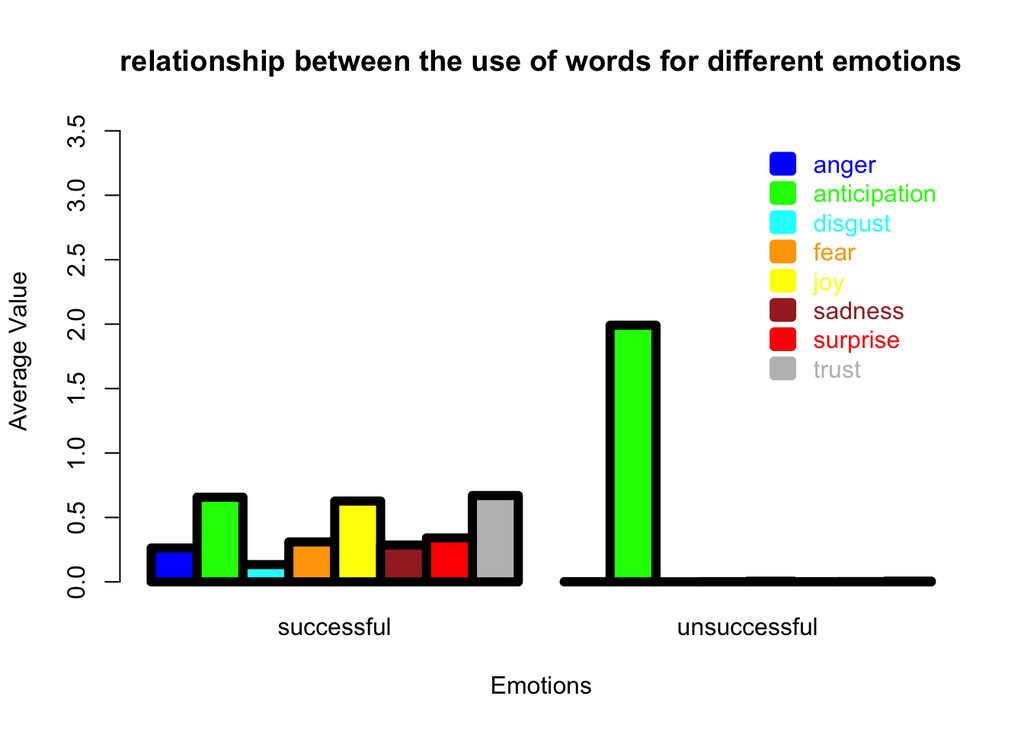

[output not shown]

```r
##code assistance from stackoverflow

cols <- c("blue", "green", "cyan", "orange", "yellow", "brown", "red","grey")
ylim <- c(0,max(data[c('anger','anticipation','disgust','fear','joy','sadness','surprise','trust')])*1.8);
par(lwd=6);
barplot(
    t(data[c('anger','anticipation','disgust','fear','joy','sadness','surprise','trust')]),
    beside=T,
    ylim=ylim,
    col=cols,
    names.arg=data$state,
    xlab='Emotions',
    ylab='Average Value',
    legend.text=c('anger','anticipation','disgust','fear','joy','sadness','surprise','trust'),
    args.legend=list(text.col=cols,col=cols,border=cols,bty='n')
) + title("relationship between the use of words for different emotions")
```